# EPKMe3_CDS_BoxPlot_Quartile

Vu Lab

Faculty of Pharmaceutical Sciences, University of British Columbia, Canada;Terry Fox Laboratory, BC Cancer Research Centre, Canada

2024-02-09

# 1 How to calculate EPKM

After C2U QC, we want to see the three replications of each condition (SCR, shRNA33, shRNA37) Here we use EPKM scatter plot as indicator to show the replications.

for the EPKM differential level analysis –> it is possible that because the EPKM values are too small –> the statistical test does not work one thing we can try is to multiply the values 10^3 to get it to the similar values we usually have for RPKM –> then run the analysis

EPKM-CDS

how to calculate EPKM (edited reads per kilobase of transcripts per million mapped reads) https://www.nature.com/articles/s41592-021-01128-0#Sec2

To calculate EPKM values for each gene, we used cumulative edit counts (T coverage over each edit site called) as determined by SAILOR (v1.1.0). We summed region-specific (either CDS or CDS and 3′ UTR, as defined by hg19 v19 Gencode annotations) edit counts for each gene and divided this number by the ‘per million’ mapped read counts to either CDS or CDS and 3′ UTR, respectively, for all genes with read counts greater than 0 as defined by Subread featureCounts (v1.5.3). We then normalized this number to the length of either the CDS or the CDS and 3′ UTR of each gene in kilobases. To assess the relationship between RPS2–STAMP and mRNA translation, we compared these per-gene EPKM values to normalized read units (RPKM values) for ribosome-protected transcripts assessed in Ribo-seq (GSE94460) and polysome-seq (GSE109423). For these analyses, we included all genes with detected read counts in either our RPS2–STAMP or ribosome-occupancy datasets.

According to this describe, we calculate EPKM as following: 1. Calculate the edited reads count for each gene by multiplying edit_site_coverage with editRatio (CDS and 3′ UTR). edited_reads = coverage * editRatio

2. Sum the edited reads counts for each gene. sum_edited_reads = sum(edited_reads)
3. divided this number by the ‘per million’ mapped read counts to either CDS or CDS and 3′ UTR, respectively, for all genes with read counts greater than 0 (my understanding: total gene expression count of each sample / 1e6). Then normalize the result to the length of the transcript in kilobases (gene_length / 1e3).

per_million_mapped_read_counts = sum(sample_sites_counts$gene_expression_counts) / 1e6 EPKM = (sum_edited_reads / per_million_mapped_read_counts) / (Length / 1e3)

# 2 import data

```r
library(tidyverse)
load(file = "output/Step03.C2U_QC.rdata")
load(file = "output/Step02.TranscriptID_Geneid_Genename.rdata")

# gene expression count
gene_count <- read.delim("Count/count.out",
                         comment.char = "#",
                         row.names = 1) %>% # set row names to the values in the first column
  select(-c(1:5)) %>%  # Use dplyr::select() to remove columns from the data frame
  rename_all(~ gsub(".bam", "", .))  # Use dplyr::rename_all() and gsub() to remove ".bam" from all column names


# Subset the gene_count data frame to include only rows where the row sum is greater than 0
gene_count <- gene_count[which(rowSums(gene_count) > 0),]

gene_length <- read.delim("Count/count.out",
                         comment.char = "#")%>%
  select(Geneid, Length)


gene_count <- as.data.frame(gene_count)
gene_count <- gene_count %>%
  rownames_to_column(var = "Geneid") %>%
  left_join(gene_length, by="Geneid")
```

# 3 EPKM-CDS -*10e3

```r
library(dplyr)

# Define function to calculate EPKM for a given sample data frame
calculate_epkm <- function(sample_df, sample_name) {
  # Rename columns and join with gene count data frame
  sample_sites_counts <- sample_df %>%
    left_join(gene_count, by = "Geneid") %>%
    rename(gene_expression_counts = !!sym(sample_name),
          coverage := paste0(sample_name, "_coverage"),
          editRatio := paste0(sample_name, "_editRatio"),
          score := paste0(sample_name, "_score")) %>%
    dplyr::select(chr, start, Geneid, Genename, biotype, Length, strand, coverage, editRatio, score, gene_expression_counts) %>%
    distinct() %>%
    filter(biotype %in% c("CDS")) %>%
    filter(gene_expression_counts > 0)

  # Calculate edited reads count and sum them for each gene
  sample_edited_reads <- sample_sites_counts %>%
    mutate(across(c(coverage, editRatio), as.numeric)) %>% # convert to numeric
    mutate(edited_reads = coverage * editRatio) %>%
    group_by(Geneid, Length, gene_expression_counts) %>%
    summarise(sum_edited_reads = sum(edited_reads), .groups = "drop")

  # Calculate EPKM

  sample_epkm <- sample_edited_reads %>%
    mutate(
      per_million_mapped_read_counts = sum(sample_sites_counts$gene_expression_counts) / 1e6,
      gene_length_kb = Length / 1e3,
      EPKM = 1e3 * (sum_edited_reads / per_million_mapped_read_counts) / gene_length_kb
    ) %>%
    dplyr::select(Geneid, EPKM) %>%
    rename(!!paste0(sample_name, "_EPKM") := EPKM)

  return(sample_epkm)
}



# Calculate EPKM for each sample
SCR_Rep1_epkm <- calculate_epkm(SCR_Rep1, "SCR_Rep1")
SCR_Rep2_epkm <- calculate_epkm(SCR_Rep2, "SCR_Rep2")
SCR_Rep3_epkm <- calculate_epkm(SCR_Rep3, "SCR_Rep3")

SCR_epkm <- SCR_Rep1_epkm %>%
  full_join(SCR_Rep2_epkm, by = "Geneid") %>%
  full_join(SCR_Rep3_epkm, by = "Geneid") %>%
  replace_na(list(SCR_Rep1_EPKM = 0, SCR_Rep2_EPKM = 0, SCR_Rep3_EPKM = 0)) %>%
  filter((SCR_Rep1_EPKM > 0 & SCR_Rep2_EPKM > 0) |
           (SCR_Rep1_EPKM > 0 & SCR_Rep3_EPKM > 0) |
           (SCR_Rep2_EPKM > 0 & SCR_Rep3_EPKM > 0))



shRNA33_Rep1_epkm <- calculate_epkm(shRNA33_Rep1, "shRNA33_Rep1")
shRNA33_Rep2_epkm <- calculate_epkm(shRNA33_Rep2, "shRNA33_Rep2")
shRNA33_Rep3_epkm <- calculate_epkm(shRNA33_Rep3, "shRNA33_Rep3")

shRNA33_epkm <- shRNA33_Rep1_epkm %>%
  full_join(shRNA33_Rep2_epkm, by = "Geneid") %>%
  full_join(shRNA33_Rep3_epkm, by = "Geneid") %>%
  replace_na(list(shRNA33_Rep1_EPKM = 0, shRNA33_Rep2_EPKM = 0, shRNA33_Rep3_EPKM = 0)) %>%
  filter((shRNA33_Rep1_EPKM > 0 & shRNA33_Rep2_EPKM > 0) |
           (shRNA33_Rep1_EPKM > 0 & shRNA33_Rep3_EPKM > 0) |
           (shRNA33_Rep2_EPKM > 0 & shRNA33_Rep3_EPKM > 0))


shRNA37_Rep1_epkm <- calculate_epkm(shRNA37_Rep1, "shRNA37_Rep1")
shRNA37_Rep2_epkm <- calculate_epkm(shRNA37_Rep2, "shRNA37_Rep2")
shRNA37_Rep3_epkm <- calculate_epkm(shRNA37_Rep3, "shRNA37_Rep3")

shRNA37_epkm <- shRNA37_Rep1_epkm %>%
  full_join(shRNA37_Rep2_epkm, by = "Geneid") %>%
  full_join(shRNA37_Rep3_epkm, by = "Geneid") %>%
  replace_na(list(shRNA37_Rep1_EPKM = 0, shRNA37_Rep2_EPKM = 0, shRNA37_Rep3_EPKM = 0)) %>%
  filter((shRNA37_Rep1_EPKM > 0 & shRNA37_Rep2_EPKM > 0) |
           (shRNA37_Rep1_EPKM > 0 & shRNA37_Rep3_EPKM > 0) |
           (shRNA37_Rep2_EPKM > 0 & shRNA37_Rep3_EPKM > 0))


# Join Geneid_epkm data frames by Geneid
gene_epkm <- SCR_epkm %>%
  full_join(shRNA33_epkm, by = "Geneid") %>%
  full_join(shRNA37_epkm, by = "Geneid")
```

# 4 Quartile_BoxPlot

for the quartile analysis with epkm –> we should use just epkm for scramble –> since the KD affects editing frequency + editing sites. quartile bins is defined based on the average value of 3 SCR samples from high to low.

```r
gene_epkm <- gene_epkm %>%
  rename_all(~ gsub("_EPKM", "", .)) %>%
  mutate_all(~ ifelse(is.na(.), 0, .))
```

# 5 SCR, shRNA cut by SCR EPKM value

```r
library(tidyverse)
library(rstatix)
library(ggpubr)


gene_epkm_bin <- gene_epkm %>%
  arrange(desc((SCR_Rep1 + SCR_Rep2 + SCR_Rep3)/3))%>%
  left_join(Geneid_Genename, by = "Geneid") %>%
  relocate(Genename, .after = Geneid)

# Calculate the number of rows in each bin
rows_per_bin <- nrow(gene_epkm_bin) / 4
# Print the number of genes in each quartile
print(paste("Each quartile genes number:", rows_per_bin))
```

```
## [1] "Each quartile genes number: 1625"
```

```r
# Add a new "bin" column based on the row index
gene_epkm_bin <- gene_epkm_bin %>%
  mutate(bin = as.integer((row_number() - 1) / rows_per_bin) + 1)




# Reshape the data to long format
long_data <- gene_epkm_bin %>%
  gather(key = "sample_Rep", value = "EPKM", SCR_Rep1, SCR_Rep2, SCR_Rep3, shRNA33_Rep1, shRNA33_Rep2, shRNA33_Rep3, shRNA37_Rep1, shRNA37_Rep2, shRNA37_Rep3) %>%
  mutate(sample_group = case_when(
    grepl("SCR", sample_Rep) ~ "SCR",
    grepl("shRNA33", sample_Rep) ~ "shRNA33",
    grepl("shRNA37", sample_Rep) ~ "shRNA37"
  )) %>%
  mutate(combined_group = case_when(
    sample_group == "SCR" ~ "SCR",
    sample_group %in% c("shRNA33", "shRNA37") ~ "shRNA"
  ))

# Perform pairwise Wilcoxon rank-sum tests
pairwise_comparisons <- long_data %>%
  group_by(bin) %>%
  pairwise_wilcox_test(EPKM ~ combined_group, p.adjust.method = "bonferroni", pool.sd = FALSE)

# Filter the significant comparisons (e.g., p-value < 0.05)
EPKM_2_significant_comparisons <- pairwise_comparisons %>%
  filter(p.adj < 0.05)

print(EPKM_2_significant_comparisons)
```

```
## # A tibble: 3 × 10
##     bin .y.   group1 group2    n1    n2 statistic        p    p.adj p.adj.signif
##   <dbl> <chr> <chr>  <chr>  <int> <int>     <dbl>    <dbl>    <dbl> <chr>
## 1     1 EPKM  SCR    shRNA   4875  9750 25289898  2.39e-10 2.39e-10 ****
## 2     2 EPKM  SCR    shRNA   4875  9750 28276983  3   e-80 3   e-80 ****
## 3     4 EPKM  SCR    shRNA   4875  9750 13086938. 0        0        ****
```

```r
# Calculate the average EPKM value for each sample group in each bin
average_EPKM <- long_data %>%
  group_by(bin, combined_group) %>%
  summarize(mean_EPKM = mean(EPKM),
            median_EPKM = median(EPKM),
            .groups = "drop")


# Print the average EPKM values
print(average_EPKM)
```

```
## # A tibble: 8 × 4
##     bin combined_group mean_EPKM median_EPKM
##   <dbl> <chr>              <dbl>       <dbl>
## 1     1 SCR               492.        51.9
## 2     1 shRNA             491.        46.7
## 3     2 SCR                 6.52       5.71
## 4     2 shRNA               6.52       3.31
## 5     3 SCR                 1.01       0.593
## 6     3 shRNA               3.02       0
## 7     4 SCR                 0          0
## 8     4 shRNA               4.97       0
```

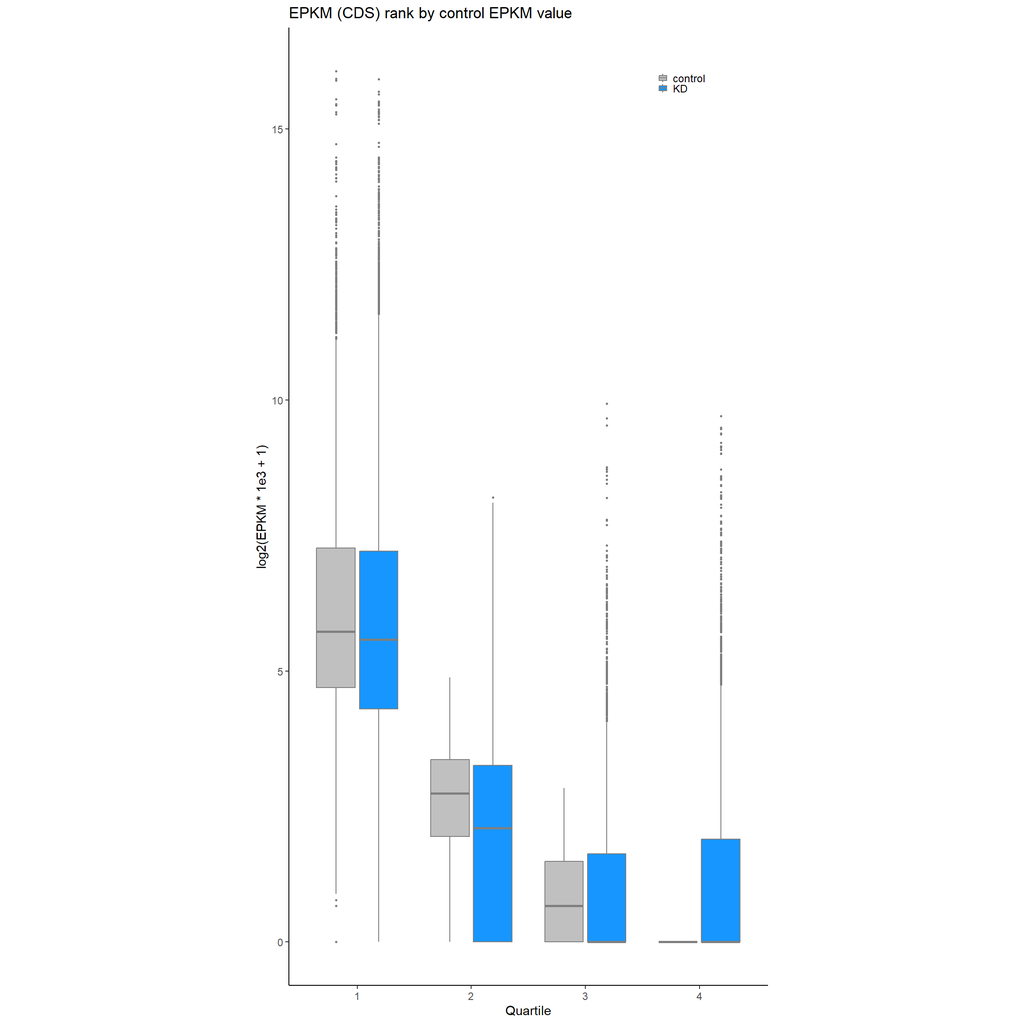

```r
# save as excel
library(openxlsx)

# Create a new workbook
wb <- createWorkbook()

# Add the data frames as sheets to the workbook
## sheet1
addWorksheet(wb, "gene_epkm")
writeData(wb, "gene_epkm", gene_epkm)

## sheet2
addWorksheet(wb, "EPKM_bins")
writeData(wb, "EPKM_bins", long_data)

## sheet3
addWorksheet(wb, "2groups_significant")
writeData(wb, "2groups_significant", EPKM_2_significant_comparisons)

## sheet4
addWorksheet(wb, "average_EPKM")
writeData(wb, "average_EPKM", average_EPKM)

# Save the workbook to a file
saveWorkbook(wb, "paper/Step05.EPKMe3_CDS_Quartile_binByEPKM_2groups.xlsx", overwrite = TRUE)



# Generate the box plot
colors <- c("#C1C0C0", "#1796FF")


EPKM_Quartile_binByEPKM_2groups <- ggplot(long_data, aes(x = as.factor(bin), y = log2(EPKM + 1), fill = combined_group)) +
  geom_boxplot(color = "grey50", outlier.size = 0.5) +
  labs(x = "Quartile", y = "log2(EPKM * 1e3 + 1)", title = "EPKM (CDS) rank by control EPKM value") +
  scale_fill_manual(values = colors, labels = c("control", "KD"), name = "") +
  theme_classic() +
  theme(legend.position = c(0.82, 0.95),
        panel.grid.major = element_blank(),
        panel.grid.minor = element_blank(),
        legend.background = element_rect(fill = "transparent", color = NA),
        legend.text = element_text(size = 9),
        legend.title = element_text(size = 9),
        legend.key.size = unit(0.3, "cm"),
        aspect.ratio = 2/1)


EPKM_Quartile_binByEPKM_2groups
```

```r
ggsave("paper/Step05.EPKMe3_CDS_Quartile_binByEPKM_2groups.pdf", plot = EPKM_Quartile_binByEPKM_2groups, device = "pdf", width = 8, height = 6)




save(gene_epkm_bin, file = "paper/Step05.EPKMe3_CDS_SCR_shRNA_EPKMbin.rdata")
```

# 6 Stats

The information of minima, maxima, center, bounds of the box and whiskers, and percentile of the boxplot:

Minima: The smallest value in the dataset, excluding any outliers. This is often represented by the end of the lower whisker in a boxplot.

Maxima: The largest value in the dataset, excluding any outliers. This is often represented by the end of the upper whisker in a boxplot.

Center: This typically refers to the median (or second quartile) of the dataset, which is the middle value when all data points are arranged in ascending order. In a boxplot, this is indicated by the line inside the box.

Bounds of the Box:

First Quartile (Q1 or lower quartile): This is the median of the lower half of the dataset (the 25th percentile). It is the lower boundary of the box in a boxplot. Third Quartile (Q3 or upper quartile): This is the median of the upper half of the dataset (the 75th percentile). It is the upper boundary of the box in a boxplot.

Whiskers: These are the lines that extend from the box to the highest and lowest values, excluding outliers. They represent the range for the bulk of the data. In many boxplots, the whiskers extend to a maximum of 1.5 times the interquartile range (IQR) from the first and third quartiles. Any data points beyond this are considered outliers.

Percentiles: These are measures that indicate the value below which a given percentage of observations in a group of observations fall. The 25th percentile corresponds to the first quartile (Q1), the 50th percentile to the median, and the 75th percentile to the third quartile (Q3).

```r
# Summary statistics for each group
boxplot_stats <- long_data %>%
  group_by(bin = as.factor(bin), combined_group) %>%
  summarise(
    min = min(EPKM, na.rm = TRUE),
    q1 = quantile(EPKM, 0.25, na.rm = TRUE),
    median = median(EPKM, na.rm = TRUE),
    q3 = quantile(EPKM, 0.75, na.rm = TRUE),
    max = max(EPKM, na.rm = TRUE),
    .groups = "keep" # Keep the grouping for subsequent calculations
  )

print(boxplot_stats)
```

```
## # A tibble: 8 × 7
## # Groups:   bin, combined_group [8]
##   bin   combined_group   min    q1 median     q3      max
##   <fct> <chr>          <dbl> <dbl>  <dbl>  <dbl>    <dbl>
## 1 1     SCR                0 24.9  51.9   153.   68863.
## 2 1     shRNA              0 18.7  46.7   148.   62140.
## 3 2     SCR                0  2.86  5.71    9.32    28.6
## 4 2     shRNA              0  0     3.31    8.57   293.
## 5 3     SCR                0  0     0.593   1.80     6.17
## 6 3     shRNA              0  0     0       2.10   979.
## 7 4     SCR                0  0     0       0        0
## 8 4     shRNA              0  0     0       2.73   833.
```

```r
# Whisker calculation
# We keep the same groups as before, no need to group_by again, since .groups was set to "keep"
whiskers <- boxplot_stats %>%
  summarise(
    ymin = pmax(min, q1 - 1.5 * (q3 - q1)), # use pmax to ensure ymin is not less than the actual min
    ymax = pmin(max, q3 + 1.5 * (q3 - q1)), # use pmin to ensure ymax is not more than the actual max
    .groups = "drop"
  )

print(whiskers)
```

```
## # A tibble: 8 × 4
##   bin   combined_group  ymin   ymax
##   <fct> <chr>          <dbl>  <dbl>
## 1 1     SCR                0 346.
## 2 1     shRNA              0 341.
## 3 2     SCR                0  19.0
## 4 2     shRNA              0  21.4
## 5 3     SCR                0   4.50
## 6 3     shRNA              0   5.24
## 7 4     SCR                0   0
## 8 4     shRNA              0   6.82
```

```r
# Save the statistics to an Excel sheet
addWorksheet(wb, "Boxplot_Statistics")
writeData(wb, "Boxplot_Statistics", boxplot_stats)

addWorksheet(wb, "Whiskers")
writeData(wb, "Whiskers", whiskers)

# Save the workbook with the new sheets
saveWorkbook(wb, "paper/Step05.EPKMe3_CDS_Quartile_Stats.xlsx", overwrite = TRUE)
```